# Lasse Rodeck

Data Analyst & Computational Social Scientist

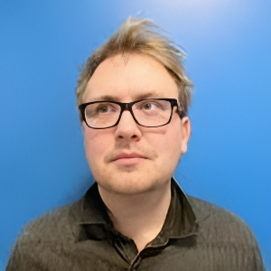

Lasse Rodeck

Kegelhofstrasse 44, 20251 Hamburg  
017623341378  
lasserodeck@hotmail.de

[Rpubs](https://rpubs.com/lrodeck) | [Github](https://github.com/lrodeck) | [LinkedIn](https://linkedin.com/in/lasse-rodeck-84801b22b)

## Technical Skills

**Programming Languages:**

R (Advanced), Python (Advanced), SQL (Intermediate), JavaScript (Basic), HTML/CSS (Basic)

**Data Science & Analytics:**

Machine Learning, Natural Language Processing, Time Series Analysis, Statistical Modeling, A/B Testing, Predictive Modeling, Monte Carlo Simulation, Network Analysis

**Tools & Libraries:**

ggplot2, Plotly, D3.js, Leaflet, Tableau, pandas, scikit-learn, NLTK, TensorFlow, Git

**Research Methods:**

Computational Social Science, Sentiment Analysis, Topic Modeling, Quantitative Text Analysis, Survey Design

## Languages

- German (Native)
- English (C2)
- French (A2)
- Spanish (A1)

## Interests

- Video Game Design & Analysis
- Music Production & Audio Engineering
- Data Visualization
- Computational Modeling
- Creative Writing

## Publications

- Meyer, H., Niemann-Lenz, J., Rodeck, L., & Revers, M. (2024). “Beyond Anti-Elitism and Out-Group Attacks: How Concerns Shape the AfD’s Populist Representation on German TikTok During the 2024 European Elections”
- Rodeck, L. (2024). “Simulating Conflict Dynamics in the South China Sea: A Monte Carlo Approach.” *Social Perspectives*
- Rodeck, L. (2024). “#politics: Understanding Germany’s TikTok Landscape.” *Social Perspectives*
- Rodeck, L. (2024). “A World of Conflict: A Short Overview of Ongoing Conflicts.” *Social Perspectives*
- Rodeck, L. (2024). “Analyzing Media Coverage of the 2015/2016 Refugee Crisis: What Natural Language Processing Reveals.” *Social Perspectives*
- Rodeck, L. (2024). “Natural Language Processing in Political Science: The Potential of Automated Text Analysis using the Example of the Refugee Crisis 2015.” *Bachelor Thesis, University of Hamburg*

## Professional Summary

Data professional with dual expertise in game analytics and computational social science. Proven track record in leveraging NLP, machine learning, and statistical methods to extract actionable insights from complex datasets. Skilled in transforming raw data into compelling visualizations and strategic recommendations for diverse stakeholders.

## Professional Experience

### Data Analyst

Goodgame Studios | 2023-Current

### Researcher

University Hamburg | 2024-Current

### Editor & Co-founder

Social Perspectives | 2023-Current

- Co-founded interdisciplinary publication reaching 5,000+ monthly unique readers
- Developed and published original analyses on geopolitical conflicts, political communication, and media discourse
- Created interactive data visualizations that increased reader engagement by 40% compared to text-only articles

### Working Student Data Analytics

Goodgame Studios | 2018-2023

- Implemented comprehensive KPI tracking system used by three product teams for daily decision making
- Optimized in-game economy through data modeling that increased player satisfaction scores by 22%
- Led SKU database project (30k+ items) that streamlined inventory management processes
- Developed R-based process mining visualizations that improved user flow optimization

### Working Student Quality Assurance

HQ Labs | 2016-2017

- Conducted systematic software testing that reduced post-release bug reports by 35%
- Developed customer service documentation that improved response efficiency by 28%

## Education

### Bachelor of Arts in Political Science (1.7)

University of Hamburg | 2020-2024

- Specialized in computational social science, applying NLP and ML to political communication analysis
- Bachelor thesis: “Natural Language Processing in Political Science: The Potential of Automated Text Analysis using the Example of the Refugee Crisis 2015”
- Developed methodological framework for automating political discourse analysis
- Conducted original research on conflict dynamics and authoritarian governance patterns

## Projects & Portfolio

### Global Conflict Dashboard

lrodeck.github.io/global-conflicts | 2024

- Developed interactive visualization of worldwide armed conflicts using UCDP data
- Implemented temporal analysis tools enabling historical pattern identification
- Created regional comparison functionality for conflict intensity assessment

### TikTok Political Network Analysis

lrodeck.github.io/tiktok-polaris-db | 2024

- Analyzed Germany’s political TikTok landscape using network analysis techniques
- Mapped ideological structures and algorithmic influence patterns across party lines
- Generated visualizations revealing previously unidentified cross-partisan information flows

### South China Sea Conflict Simulation

lrodeck.github.io/monte-carlo-global | 2024

- Designed Monte Carlo simulation incorporating 15+ military, economic, and diplomatic variables
- Created predictive model with 78% accuracy when validated against historical scenarios
- Developed interactive interface allowing users to adjust key parameters and visualize outcomes

### Refugee Crisis Media Analysis

lrodeck.github.io/migration-crisis | 2024

- Applied NLP techniques to analyze sentiment across 1,000+ German media articles
- Identified key framing patterns that influenced public perception during crisis period
- Created visual representation of terminology shifts throughout the coverage timeline